# Analysis, and Visualization, of Quantitative Client Feedback Survey

by John Akwei, Data Science Specialist

Monday, September 14, 2015

## Synopsis

This document is an analysis and visualization of the responses to the client feedback survey.

Through processing of the Data, in the R programming language, was performed to extract the conclusions in this Document. Most of the R coding was left out of the rendering of this Document, in order to increase comprehensibility.

The sections of this Document include:  
1) Data import  
2) Data Summary  
3) Client Feedback Survey Overview  
4) Customer Analysis  
5) Response Analysis Plots  
6) Survey Response WordClouds

### Importing survey response data tables:

```r
dt <- read.csv("clientfeedback.csv", check.names=F)
```

### Data Summary:

```
## 'data.frame':    249 obs. of  14 variables:
##  $ #                                                                                                       : Factor w/ 249 levels "0116d22b217f17654c90157b166b0513",..: 137 114 171 190 88 46 89 102 158 132 ...
##  $ What led you to DexaFit?                                                                                : Factor w/ 241 levels "","1) I want to be ripped. 2) i want to monitor changes in lean mass, to see if my workout and diet plans are having the effects I"| __truncated__,..: 64 1 1 1 1 238 …
##  $ What did you enjoy learning most during your visit with us?                                             : Factor w/ 241 levels "","% of muscle mass",..: 54 1 1 1 1 7 1 1 72 95 ...
##  $ How are you using the feedback from your tests to improve your fitness and health?                      : Factor w/ 242 levels "","1) target weight loss established 2) ask for help from coaches to achieve 1. 3) it is really pitty but - i DO NOT understand ye"| __truncated__,..: 40 1 1 1 1 232 …
##  $ Do you prefer to pay for your testing in full in one payment or in installments over a period of months?: Factor w/ 3 levels "","  I want to make one payment, like I do now.  ",..: 1 1 1 1 1 1 1 1 1 1 ...
##  $ Other                                                                                                   : Factor w/ 14 levels "","Already paid in full for \"before and after\" body-composition tests.",..: 1 1 1 1 1 1 1 1 1 1 ...
##  $ How often would you like to test throughout the year if we offered a simple monthly payment plan?       : Factor w/ 53 levels "","1-2 times per year",..: 1 1 1 1 1 1 1 1 1 1 ...
##  $ How would you describe us to a friend?                                                                  : Factor w/ 242 levels ""," a great tool.",..: 72 1 1 1 1 177 1 1 122 215 ...
##  $ Do you have any big questions, roadblocks, concerns, or ideas?                                          : Factor w/ 190 levels "","1) i still do not have access to my online results (or am i missing it ? spam?) 2) the MOST important piece of advice is the RE"| __truncated__,..: 26 1 1 1 1 29 1…
##  $ What's your favorite website for fitness and nutrition?                                                 : Factor w/ 131 levels "","http://","http://.",..: 1 1 1 1 1 1 1 1 1 1 ...
##  $ What's your email address?                                                                              : Factor w/ 242 levels "","140in2012@gmail.com",..: 1 1 1 1 1 1 1 1 189 61 ...
##  $ Start Date (UTC)                                                                                        : Factor w/ 249 levels "2015-08-28 20:04:10",..: 1 2 3 4 5 6 7 8 9 10 ...
##  $ Submit Date (UTC)                                                                                       : Factor w/ 248 levels "2015-08-28 20:04:28",..: 1 2 3 4 5 6 7 8 9 10 ...
##  $ Network ID                                                                                              : Factor w/ 238 levels "01a73cf71d","01b0851656",..: 100 100 100 100 100 6 100 100 100 120 ...
```

### Client Feedback Survey Overview:

#### There are 10 questions in the client feedback survey.

#### The number of clients that responded to the survey is 249.

#### The client feedback survey asked the following 10 questions:

“What led you to DexaFit?”  
“What did you enjoy learning most during your visit with us?”  
“How are you using the feedback from your tests to improve your fitness and health?”  
“Do you prefer to pay for your testing in full in one payment or in installments over a period of months?”  
“Other”  
“How often would you like to test throughout the year if we offered a simple monthly payment plan?”  
“How would you describe us to a friend?”  
“Do you have any big questions, roadblocks, concerns, or ideas?”  
“What’s your favorite website for fitness and nutrition?”  
“What’s your email address?”

### Customer Analysis

#### In response to “What led you to DexaFit?”, customers mentioned:

The term, “Body”, was mentioned 92 times by customers.  
The term, “Fat”, was mentioned 78 times by customers. The term, “Weight”, was mentioned 44 times by customers.  
The term, “Accurate”, was mentioned 26 times by customers.  
The term, “Fitness”, was mentioned 21 times by customers.  
The term, “Curious”, was mentioned 8 times by customers.

The longest response to this question contained 499 characters.

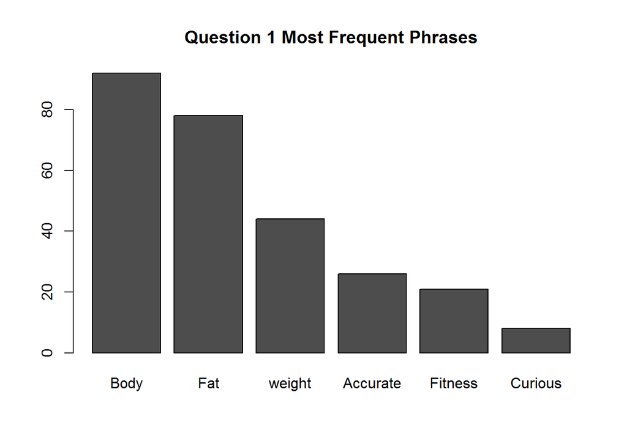

#### In response to “What did you enjoy learning most during your visit with us?”, customers mentioned:

The term, “Density”, was mentioned 22 times by customers.  
The term, “Mass”, was mentioned 21 times by customers.  
The term, “Muscle”, was mentioned 16 times by customers. The term, “Results”, was mentioned 16 times by customers.  
The term, “Enjoyed”, was mentioned 14 times by customers.  
The term, “Learning”, was mentioned 13 times by customers.

The longest response to this question contained 462 characters.

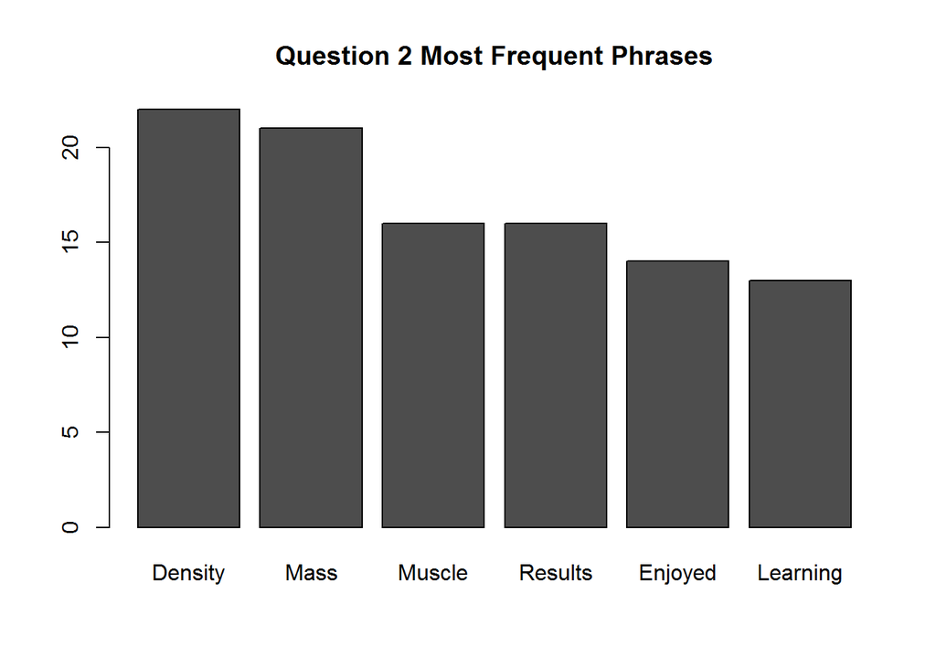

#### In response to “How are you using the feedback from your tests to improve your fitness and health?”, customers mentioned:

The term, “Diet”, was mentioned 38 times by customers.  
The term, “Exercise”, was mentioned 26 times by customers. The term, “Baseline”, was mentioned 16 times by customers. The term, “Will”, was mentioned 14 times by customers.  
The term, “Workouts”, was mentioned 13 times by customers. The term, “Intake”, was mentioned 13 times by customers.  
The term, “Changes”, was mentioned 10 times by customers.

The longest response to this question contained 389 characters.

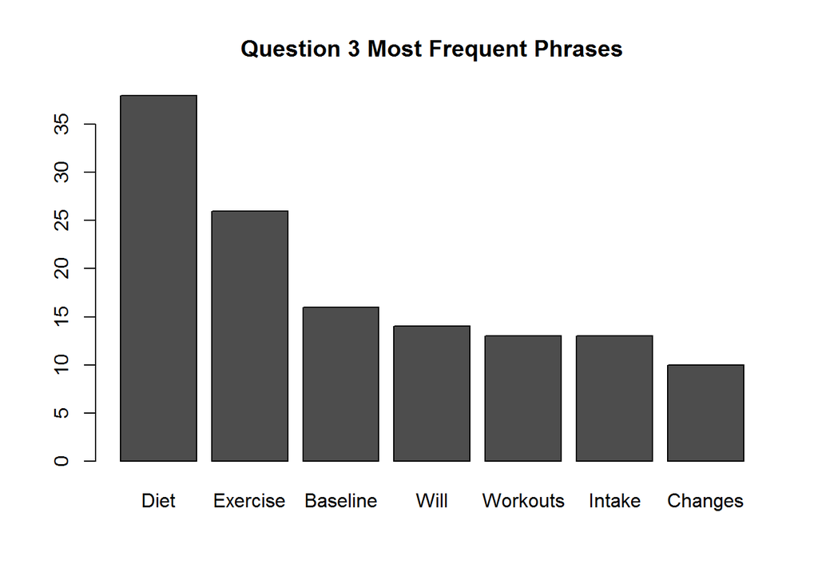

#### In response to “Do you prefer to pay for your testing in full in one payment or in installments over a period of months?”, Customers selected:

“I want to test more frequently! Please offer monthly payment plans.”, 55 times.  
“I want to make one payment, like I do now.”, 170 times.

#### Responses to “Other”:

I think this is discretionary spending so people should be able to pay up front, but I would love a membership discount for buying three tests over a year plan.

the results were poorly displayed and not helpful

Already paid in full for “before and after” body-composition tests.

Either. Monthly payments may allow me to think of more regular testing but not a biggie

Doesn’t really matter to me. I don’t know how frequently I will be getting tested

Pay for a series of tests (one payment preferable to a subscription fee)

Single payment as long as there is a discount.

I don’t know. It would depend on the pricing. Are you going to offer bulk deals? One test doesn’t do much… There is a lot of noise in thr neasurements.

pay as i go.

I did not pay as a study participant

#### In response to, “How often would you like to test throughout the year if we offered a simple monthly payment plan?, customers prefered 3-4 times/year:

Statistical proof of preference for “3-4 times/year”:  
“3” mentioned 18 times  
“4” mentioned 20 times  
“3-4” mentioned 4 times  
“2” mentioned 13 times  
“1” mentioned 5 times  
“1-2” mentioned 2 times  
“5” mentioned 3 times  
“once” mentioned 3 times  
“twice” mentioned 2 times  
“quarterly” mentioned 2 times

#### In response to “How would you describe us to a friend?”, customers mentioned:

The term, “Fat”, was mentioned 37 times by customers.  
The term, “Accurate”, was mentioned 34 times by customers.  
The term, “Composition”, was mentioned 31 times by customers. The term, “Best”, was mentioned 14 times by customers. The term, “Easy”, was mentioned 14 times by customers.  
The term, “Good”, was mentioned 8 times by customers.  
The term, “Quick”, was mentioned 6 times by customers.  
The term, “Awesome”, was mentioned 2 times by customers.

The longest response to this question contained 302 characters.

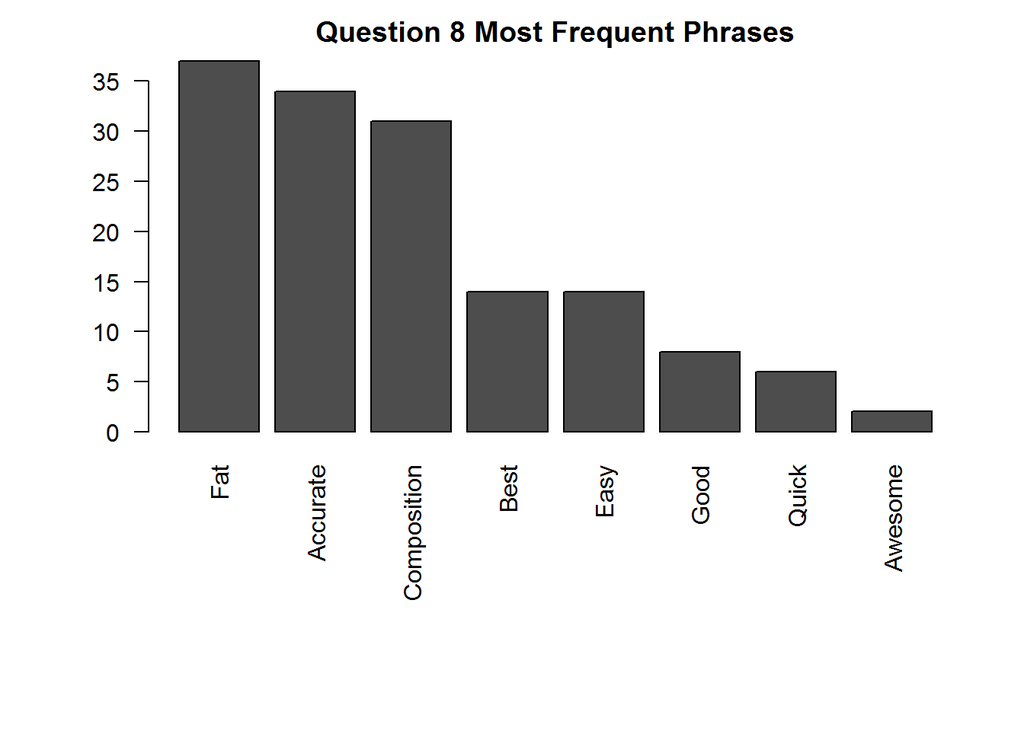

#### In response to “Do you have any big questions, roadblocks, concerns, or ideas?”, customers mentioned:

The term, “Test”, was mentioned 32 times by customers. The term, “Tests”, was mentioned 12 times by customers.  
The term, “Results”, was mentioned 16 times by customers.  
The term, “Information”, was mentioned 12 times by customers. The term, “Questions”, was mentioned 6 times by customers.  
The term, “Nope”, was mentioned 7 times by customers.  
The term, “None”, was mentioned 3 times by customers.

The longest response to this question contained 701 characters.s

#### In response to “What’s your favorite website for fitness and nutrition?”, customers mentioned:

“bodybuilder.com”, was mentioned 17 times by customers. “myfitnesspal.com”, was mentioned 17 times by customers.  
“google.com”, was mentioned 10 times by customers.  
“reddit.com/r/fitness”, was mentioned 7 times by customers.  
“marksdailyapple.com”, was mentioned 5 times by customers. “t-nation.com”, was mentioned 5 times by customers. “bengreenfieldfitnesa.com”, was mentioned 4 times by customers.

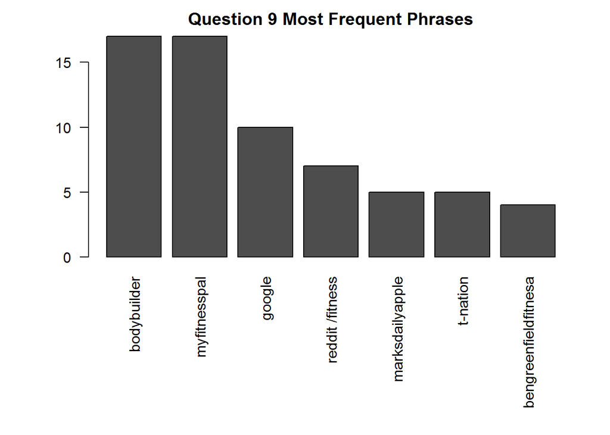

### WordCloud for “What led you to DexaFit?”:

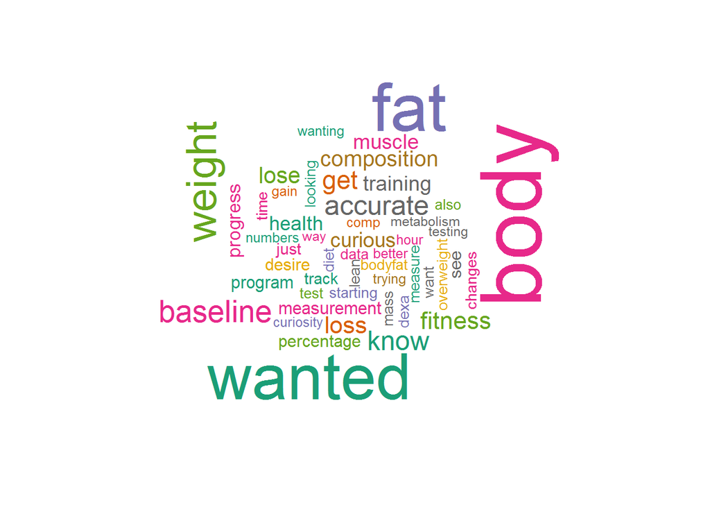

### WordCloud for “What did you enjoy learning most during your visit with us?”:

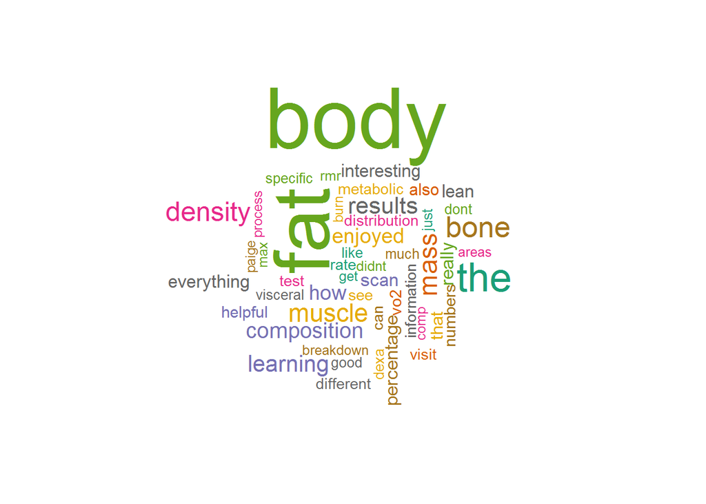

### WordCloud for “How are you using the feedback from your tests to improve your fitness and health?”:

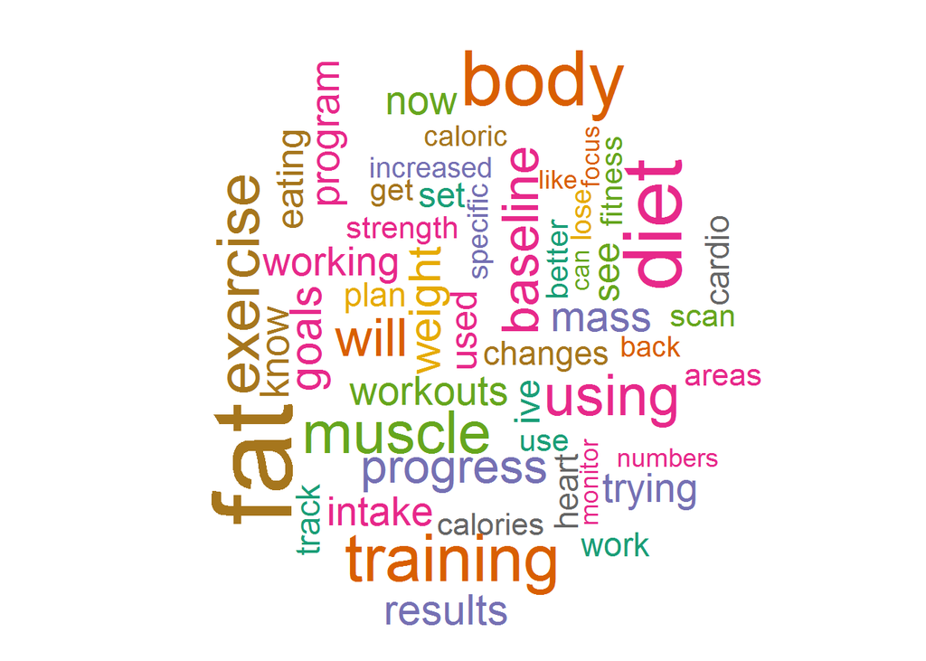

### WordCloud for “How would you describe us to a friend?”:

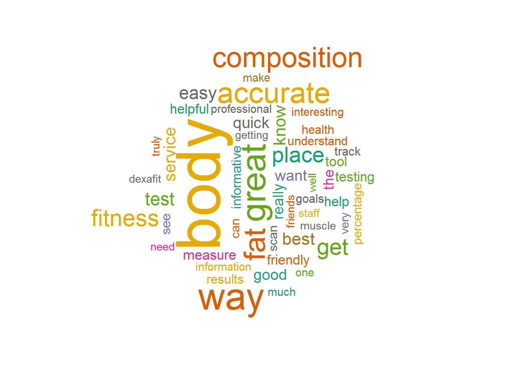

### WordCloud for “Do you have any big questions, roadblocks, concerns, or ideas?”:

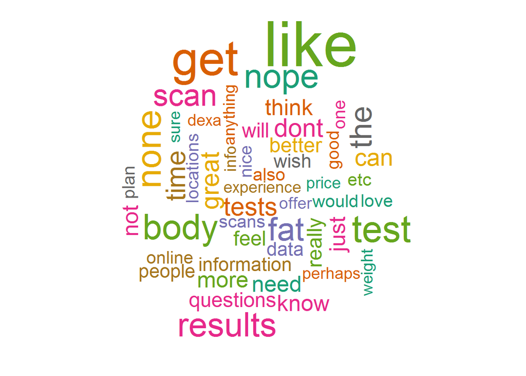